# epicPCR

##Get packages which are needed for analysis

We will use Phyloseq package which is a handy tool developed for 16S amplicon analysis, but can be used for all kinds of datasets with several tables.

```r
library(phyloseq)
```

```r
library(ggplot2)
```

##Read in OTU table, tax table and sample data

```r
#OTU table
OTU<-read.table("16S_OTUs.txt", sep="\t", fill= 1, header=TRUE, row.names = 1)
#Taxonomy table
tax<-read.table("16S.tax", header=FALSE, sep="\t", row.names = 1)
#Sample data
sample_data<-read.table("sample_data", header=TRUE, sep="\t", row.names = 1)
sample_data$Sample_type<-paste(sample_data$Gene, sample_data$Plant, sample_data$Treatment, sep="_")
#Merge into a phyloseq object
epic<-phyloseq(otu_table((OTU), taxa_are_rows = TRUE), tax_table(as.matrix(tax)), sample_data(sample_data))
#Change the column names to something meaningful in the taxonomy table
colnames(tax_table(epic)) <- c("Domain","Phylum", "Class", "Order", "Family", "Genus", "Species")
#Check sample sums
sample_sums(epic)
```

```
##    blaOXA_SU_I1    blaOXA_SU_I2    blaOXA_SU_I3    blaOXA_SU_O1
##             160            4706           66349              10
##    blaOXA_SU_O2    blaOXA_SU_O3    blaOXA_VI_I1    blaOXA_VI_I2
##            3847           24747           53071           18282
##    blaOXA_VI_I3    blaOXA_VI_O1    blaOXA_VI_O2    blaOXA_VI_O3
##           33669             681            3440            8904
##    blaOXA_VI_S3      int1_VI_I2      int1_VI_I3      int1_VI_O3
##               1              19               4             758
## qacEdelta_SU_I1 qacEdelta_SU_I2 qacEdelta_SU_I3 qacEdelta_SU_O1
##           22124              57           26469               4
## qacEdelta_SU_O2 qacEdelta_SU_O3 qacEdelta_SU_U2 qacEdelta_VI_I1
##            1229              20               1           62601
## qacEdelta_VI_I2 qacEdelta_VI_I3 qacEdelta_VI_O1 qacEdelta_VI_O2
##           29806           47880              12              87
## qacEdelta_VI_O3      tetM_SU_I1      tetM_SU_I2      tetM_SU_I3
##              11           26392              13           40366
##      tetM_SU_O1      tetM_SU_O2      tetM_SU_O3      tetM_VI_I1
##            2545              39           42195           29145
##      tetM_VI_I2      tetM_VI_I3      tetM_VI_O1      tetM_VI_O2
##           26511           39281            9746              37
##      tetM_VI_O3
##            4450
```

```r
#Check Phyloseq object
epic#We have 4250 identified taxa and 41 samples before preprocessing data
```

```
## phyloseq-class experiment-level object
## otu_table()   OTU Table:         [ 4250 taxa and 41 samples ]
## sample_data() Sample Data:       [ 41 samples by 5 sample variables ]
## tax_table()   Taxonomy Table:    [ 4250 taxa by 7 taxonomic ranks ]
```

##Preprocessing of the data

*Some of the replicates didn’t have a lot of amplification, so we will remove all samples that have less than 40 reads.

*We will also glomerate the results to genus level. This will allow us to explore if a resistance gene or an MGE is found in a bacterial genus. For the porposes of our study it is not meaningful to explore the host range of genes on a lower taxonomic level.

*Since epicPCR is not quatitative we will change the abundances of the OTUs to 0 or 1 if the genus was in a host of the gene or not. This will change the data so that is is presence/absence based. We will consider even 1 read as a positive match in this analysis to reproduce Jenni’s results. For your own data you might want to consider filtering out genera that have less than x number of reads mapping to it.

*We will also only consider genera as host if the genus was seen in 2/3 or 2/2 biological replicates after removal of bad samples.

```r
#Remove samples which have less than 40 reads
epic_goodSamples<-subset_samples(epic, sample_sums(epic)>40)
#Check Phyloseq object
epic_goodSamples#We are left with 29 samples. Number of taxa didn't change because we didn't remove any taxa
```

```
## phyloseq-class experiment-level object
## otu_table()   OTU Table:         [ 4250 taxa and 29 samples ]
## sample_data() Sample Data:       [ 29 samples by 5 sample variables ]
## tax_table()   Taxonomy Table:    [ 4250 taxa by 7 taxonomic ranks ]
```

```r
#Glomerate to genus level
epic_genus<-tax_glom(epic_goodSamples, taxrank="Genus")
#Check Phyloseq object
epic_genus#Now we have less taxa 382, because we combined taxa on species level to genus level
```

```
## phyloseq-class experiment-level object
## otu_table()   OTU Table:         [ 382 taxa and 29 samples ]
## sample_data() Sample Data:       [ 29 samples by 5 sample variables ]
## tax_table()   Taxonomy Table:    [ 382 taxa by 7 taxonomic ranks ]
```

```r
#Change to presence absence
epic_genus_pres<-otu_table(epic_genus)
otu_table(epic_genus_pres)[otu_table(epic_genus_pres)>0]<-1
epic_genus_pres<-phyloseq(otu_table(epic_genus_pres), sample_data(sample_data), tax_table(as.matrix(tax_table(epic_genus))))
#Merge biological replicates using Phyloseq
epic_genus_mrg<-merge_samples(epic_genus_pres, "Sample_type")
#Change all values less than 2 to 0 and more than 1 to  1 get presence absence data again
epic_genus_mrg_pres<-otu_table(epic_genus_mrg)
otu_table(epic_genus_mrg_pres)[otu_table(epic_genus_mrg_pres)<2]<-0
otu_table(epic_genus_mrg_pres)[otu_table(epic_genus_mrg_pres)>1]<-1
epic_genus_mrg_pres<-phyloseq(otu_table(epic_genus_mrg_pres), sample_data(epic_genus_mrg), tax_table(as.matrix(tax_table(epic_genus))))
#Remove taxa which are not detected
epic_FINAL<-subset_taxa(epic_genus_mrg_pres, taxa_sums(epic_genus_mrg_pres)>0)
#Explore the new phyloseq object
epic_FINAL#Now we have 222 taxa and 13 samples
```

```
## phyloseq-class experiment-level object
## otu_table()   OTU Table:         [ 222 taxa and 13 samples ]
## sample_data() Sample Data:       [ 13 samples by 5 sample variables ]
## tax_table()   Taxonomy Table:    [ 222 taxa by 7 taxonomic ranks ]
```

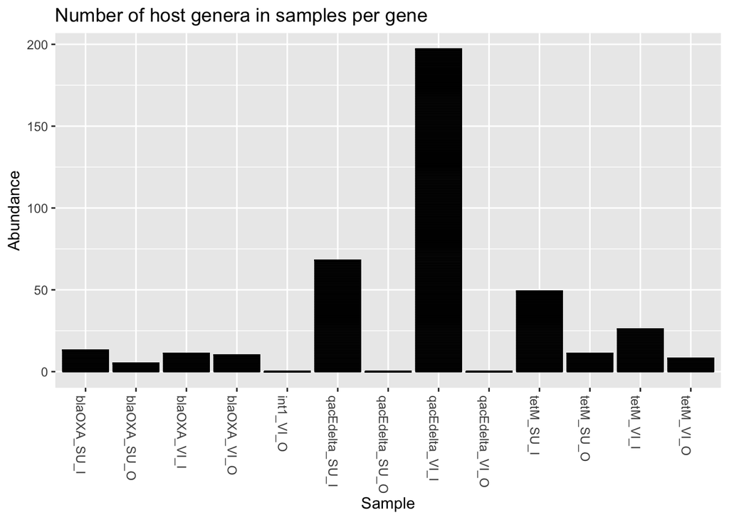

```r
#Plot the number of different genera in samples per gene
plot_bar(epic_FINAL, "Sample", title = "Number of host genera in samples per gene")
```

```r
sort(taxa_sums(epic_FINAL), decreasing = TRUE)
```

```
##    OTU1   OTU12   OTU25  OTU309   OTU78  OTU161   OTU20   OTU30   OTU75
##      10      10       7       6       6       5       5       5       5
##   OTU77   OTU91  OTU107  OTU219 OTU2258  OTU226  OTU338 OTU3725  OTU460
##       5       5       4       4       4       4       4       4       4
##   OTU74   OTU82   OTU95  OTU123  OTU139  OTU148  OTU157  OTU166  OTU224
##       4       4       4       3       3       3       3       3       3
##  OTU263 OTU3032 OTU3727  OTU510  OTU517  OTU685   OTU70   OTU80   OTU81
##       3       3       3       3       3       3       3       3       3
##   OTU83   OTU92  OTU110 OTU1108  OTU116  OTU122  OTU125  OTU126  OTU129
##       3       3       2       2       2       2       2       2       2
##  OTU135  OTU140  OTU141  OTU142  OTU152  OTU163  OTU174  OTU180  OTU185
##       2       2       2       2       2       2       2       2       2
##  OTU189  OTU191  OTU198  OTU211  OTU213  OTU215  OTU268 OTU2755  OTU278
##       2       2       2       2       2       2       2       2       2
##  OTU281  OTU285  OTU293  OTU297  OTU307  OTU337  OTU352  OTU355 OTU3735
##       2       2       2       2       2       2       2       2       2
## OTU3736 OTU3743 OTU3744 OTU3748 OTU3765 OTU3771 OTU3780 OTU3788  OTU496
##       2       2       2       2       2       2       2       2       2
##  OTU554  OTU555   OTU64  OTU670  OTU722   OTU73   OTU85   OTU86   OTU88
##       2       2       2       2       2       2       2       2       2
##   OTU93   OTU94 OTU1050  OTU106 OTU1083   OTU11 OTU1147 OTU1160  OTU120
##       2       2       1       1       1       1       1       1       1
## OTU1218 OTU1309  OTU132 OTU1326 OTU1338  OTU149  OTU150 OTU1525 OTU1531
##       1       1       1       1       1       1       1       1       1
## OTU1564  OTU158 OTU1588 OTU1589  OTU159 OTU1591 OTU1593 OTU1595 OTU1619
##       1       1       1       1       1       1       1       1       1
## OTU1638  OTU182  OTU183 OTU1834  OTU186 OTU1972    OTU2  OTU200  OTU204
##       1       1       1       1       1       1       1       1       1
## OTU2069 OTU2090  OTU214  OTU216  OTU217  OTU222  OTU225  OTU236  OTU247
##       1       1       1       1       1       1       1       1       1
##  OTU252  OTU253  OTU256  OTU260  OTU264  OTU267  OTU273  OTU276  OTU280
##       1       1       1       1       1       1       1       1       1
##  OTU288  OTU290  OTU291  OTU294 OTU2953 OTU2976  OTU299 OTU3000  OTU313
##       1       1       1       1       1       1       1       1       1
## OTU3187 OTU3204  OTU322 OTU3224  OTU342  OTU343  OTU348  OTU358  OTU361
##       1       1       1       1       1       1       1       1       1
## OTU3732 OTU3733 OTU3742 OTU3750 OTU3755 OTU3758 OTU3782 OTU3784 OTU3791
##       1       1       1       1       1       1       1       1       1
## OTU3797 OTU3813  OTU382 OTU3826 OTU3827 OTU3837  OTU391 OTU3963  OTU397
##       1       1       1       1       1       1       1       1       1
## OTU3977 OTU3984  OTU411 OTU4121  OTU422  OTU425  OTU435  OTU461  OTU468
##       1       1       1       1       1       1       1       1       1
##  OTU474  OTU478  OTU480  OTU486  OTU491  OTU497  OTU509  OTU511  OTU549
##       1       1       1       1       1       1       1       1       1
##  OTU568  OTU569  OTU570  OTU572  OTU575  OTU603  OTU664  OTU667  OTU688
##       1       1       1       1       1       1       1       1       1
##  OTU701  OTU764  OTU808  OTU810  OTU822  OTU826   OTU84  OTU880  OTU881
##       1       1       1       1       1       1       1       1       1
##  OTU884  OTU952  OTU954  OTU959  OTU965  OTU981
##       1       1       1       1       1       1
```

```r
#Get taxa names
tax_table(epic_FINAL)[,6]
```

```
## Taxonomy Table:     [222 taxa by 1 taxonomic ranks]:
##         Genus
## OTU1    "Fusobacteriaceae_unclassified"
## OTU1050 "Draconibacteriaceae_unclassified"
## OTU106  "Bdellovibrio"
## OTU107  "Prevotella_9"
## OTU1083 "Thiothrix"
## OTU11   "Tyzzerella"
## OTU110  "Rivicola"
## OTU1108 "Porphyromonadaceae_unclassified"
## OTU1147 "M2PB4-65_termite_group_unclassified"
## OTU116  "Macellibacteroides"
## OTU1160 "Rhodobacteraceae_unclassified"
## OTU12   "Arcobacter"
## OTU120  "Defluviimonas"
## OTU1218 "Lachnospiraceae_UCG-003"
## OTU122  "Comamonas"
## OTU123  "Aeromonadaceae_unclassified"
## OTU125  "Bacteroidales_unclassified"
## OTU126  "Formivibrio"
## OTU129  "Anaerosporobacter"
## OTU1309 "Burkholderiales_unclassified"
## OTU132  "Bacteriovorax"
## OTU1326 "Petrimonas"
## OTU1338 "Alcaligenaceae_unclassified"
## OTU135  "Leptotrichia"
## OTU139  "Microbacter"
## OTU140  "Roseburia"
## OTU141  "Citrobacter"
## OTU142  "Defluviitaleaceae_UCG-011"
## OTU148  "Leptotrichiaceae_unclassified"
## OTU149  "Zoogloea"
## OTU150  "Christensenellaceae_R-7_group"
## OTU152  "Laribacter"
## OTU1525 "Azonexus"
## OTU1531 "Holophagaceae_unclassified"
## OTU1564 "Extensimonas"
## OTU157  "Bacteroides"
## OTU158  "DB1-14_unclassified"
## OTU1588 "Ruminococcaceae_UCG-005"
```

[output cut: 169 more lines]

```
## OTU86   "Cloacibacterium"
## OTU88   "Propionivibrio"
## OTU880  "Dorea"
## OTU881  "Prevotellaceae_unclassified"
## OTU884  "Geovibrio"
## OTU91   "Gracilibacteria_unclassified"
## OTU92   "Flavobacterium"
## OTU93   "Rhodocyclaceae_unclassified"
## OTU94   "Vitreoscilla"
## OTU95   "Paludibacter"
## OTU952  "Stenotrophomonas"
## OTU954  "Lactonifactor"
## OTU959  "Wolinella"
## OTU965  "ST-12K33_unclassified"
## OTU981  "Methylotenera"
```

```r
table<-as.data.frame(t(otu_table(epic_FINAL)))
table$Genus<-c(tax_table(epic_FINAL)[,6])
df<-data.frame(SUM=rowSums(table[,1:13]), Genus=table[,14])
sort(df$SUM, decreasing=TRUE)
```

```
##   [1] 10 10  7  6  6  5  5  5  5  5  5  4  4  4  4  4  4  4  4  4  4  3  3
##  [24]  3  3  3  3  3  3  3  3  3  3  3  3  3  3  3  2  2  2  2  2  2  2  2
##  [47]  2  2  2  2  2  2  2  2  2  2  2  2  2  2  2  2  2  2  2  2  2  2  2
##  [70]  2  2  2  2  2  2  2  2  2  2  2  2  2  2  2  2  2  2  2  2  2  2  2
##  [93]  1  1  1  1  1  1  1  1  1  1  1  1  1  1  1  1  1  1  1  1  1  1  1
## [116]  1  1  1  1  1  1  1  1  1  1  1  1  1  1  1  1  1  1  1  1  1  1  1
## [139]  1  1  1  1  1  1  1  1  1  1  1  1  1  1  1  1  1  1  1  1  1  1  1
## [162]  1  1  1  1  1  1  1  1  1  1  1  1  1  1  1  1  1  1  1  1  1  1  1
## [185]  1  1  1  1  1  1  1  1  1  1  1  1  1  1  1  1  1  1  1  1  1  1  1
## [208]  1  1  1  1  1  1  1  1  1  1  1  1  1  1  1
```